# Revision: Results - FHIR Review

Lehne, Vorisek

20 4 2022

# Network Analysis

First, load relevant packages for the network analysis:

```r
library(tidyverse)
library(igraph)
library(ggraph)
library(visNetwork)
library(readxl)
```

## Read in the articles (“articles.xlsx” was exported from Rayyan):

```r
library(readxl)
articles <- read_excel("articles.xlsx")
head(articles)
```

```
## # A tibble: 6 x 19
##   key    title   year month   day journal issn  volume issue pages authors url
##   <chr>  <chr>  <dbl> <dbl> <dbl> <chr>   <chr>  <dbl> <dbl> <chr> <chr>   <chr>
## 1 rayya~ An FH~  2017    NA    NA 2017 I~ 2472~     NA    NA 44652 F. Kha~ <NA>
## 2 rayya~ Fast ~  2021    11    18 Studie~ 1879~    287    NA 73-77 Klopfe~ http~
## 3 rayya~ A Fra~  2021     4     1 JMIR m~ 2291~      9     4 e256~ Gruend~ http~
## 4 rayya~ REDCa~  2021     9    NA Journa~ 1532~    121    NA 1038~ Cheng ~ http~
## 5 rayya~ Proto~  2021     1    12 JMIR m~ 2291~      9     1 e204~ Gulden~ http~
## 6 rayya~ Use o~  2021     5    24 Studie~ 1879~    278    NA 156-~ Rinald~ http~
## # ... with 7 more variables: language <chr>, publisher <lgl>, location <chr>,
## #   abstract <lgl>, notes <chr>, pubmed_id <lgl>, pmc_id <lgl>
```

Select relevant variables (title and authors of papers), reformat author names, make sure only included articles are considered, correct some author names for consistency, and create variable with list of authors:

```r
articles_clean <- articles %>%
        select(title, authors) %>%
        mutate(authors = str_remove_all(authors, "[.,]")) %>%
        mutate(authors = ifelse(authors == "F Khalique and S A Khan",
                                 "Khalique F and Khan SA", authors)) %>%
        mutate(authors = str_replace_all(authors, " ", "_")) %>%
        mutate(authors = str_replace_all(authors, "_and_", " ")) %>%
        mutate(authors = str_replace(authors, "Agrawal_Asha", "Agrawal_A")) %>%
        mutate(authors = str_replace(authors, "Broadbent_Matthew", "Broadbent_M")) %>%
        mutate(authors = str_replace(authors, "Dobson_Richard_J_B", "Dobson_RJB")) %>%
        mutate(authors = str_replace(authors, "Folarin_Amos", "Folarin_A")) %>%
        mutate(authors = str_replace(authors, "Gale_Darren", "Gale_D")) %>%
        mutate(authors = str_replace(authors, "Gorrell_Genevieve", "Gorrell_G")) %>%
        mutate(authors = str_replace(authors, "Hansen_D", "Hansen_DP")) %>%
        mutate(authors = str_replace(authors, "Hansen_DPP", "Hansen_DP")) %>%
        mutate(authors = str_replace(authors, "Ibrahim_Zina_M", "Ibrahim_ZM")) %>%
        mutate(authors = str_replace(authors, "Jackson_Richard", "Jackson_R")) %>%
        mutate(authors = str_replace(authors, "Kartoglu_Ismail", "Kartoglu_I")) %>%
        mutate(authors = str_replace(authors, "Morley_Katherine_I", "Morley_KI")) %>%
        mutate(authors = str_replace(authors, "Roberts_Angus", "Roberts_A")) %>%
        mutate(authors = str_replace(authors, "Stewart_Robert", "Stewart_R")) %>%
        mutate(authors = str_replace(authors, "Stringer_Clive", "Stringer_C")) %>%
        mutate(authors = str_replace(authors, "Toti_Giulia", "Toti_G")) %>%
        mutate(authors = str_replace(authors, "Wu_Honghan", "Wu_HH")) %>%
        mutate(authors_list = str_split(authors, " "))

head(articles_clean)
```

```
## # A tibble: 6 x 3
##   title                            authors                          authors_list
##   <chr>                            <chr>                            <list>
## 1 An FHIR-based Framework for Con~ Khalique_F Khan_SA               <chr [2]>
## 2 Fast Healthcare Interoperabilit~ Klopfenstein_SAI Vorisek_CN Shu~ <chr [8]>
## 3 A Framework for Criteria-Based ~ Gruendner_J Gulden_C Kampf_M Ma~ <chr [6]>
## 4 REDCap on FHIR: Clinical Data I~ Cheng_AC Duda_SN Taylor_R Delac~ <chr [8]>
## 5 Prototypical Clinical Trial Reg~ Gulden_C Blasini_R Nassirian_A ~ <chr [8]>
## 6 Use of LOINC and SNOMED CT with~ Rinaldi_E Saas_J Thun_S          <chr [3]>
```

## Network of authors

Create dataframe with authors and their numbers of publications:

```r
# all authors
authors <- unlist(articles_clean$authors_list) %>%
        unique() %>%
        data.frame(author = .) %>%
        mutate(author = as.character(author), publications = 0) %>%
        arrange(author)

# add number of publications per author
for (i in 1:nrow(authors)) {
        a <- authors$author[i]
        for (j in 1:nrow(articles_clean)) {
                authorlist <- unlist(articles_clean$authors_list[j])
                if (a %in% authorlist) {
                        authors$publications[i] <- authors$publications[i] + 1
                }
        }
}
```

## Get combinations of authors and count their number of co-authorships:

```r
# construct dataframe with all combinations of authors
author1 = character()
author2 = character()

for (i in 1:(nrow(authors)-1)) {
        for (j in ((i+1):nrow(authors))) {
                author1 <- c(author1, authors$author[i])
                author2 <- c(author2, authors$author[j])
        }

}

# tibble with authors
author_coll <- tibble(author1, author2, collaborations = 0)

# count collaborations for all author combinations
for (i in 1:nrow(author_coll)) {

        a1 <- author_coll$author1[i]
        a2 <- author_coll$author2[i]

        for (j in 1:nrow(articles_clean)) {

                authorlist <- unlist(articles_clean$authors_list[j])

                if (a1 %in% authorlist & a2 %in% authorlist) {
                        author_coll$collaborations[i] <- author_coll$collaborations[i] + 1
                }
        }
}
```

## Prepare network object:

```r
# edgelist (authors with collaborations)
edgelist_authors <- author_coll %>%
        filter(collaborations > 0) %>%
        arrange(desc(collaborations))

# create network object
network_authors <- graph_from_data_frame(edgelist_authors, directed = FALSE,
                                         vertices = authors)
```

### Plot the network:

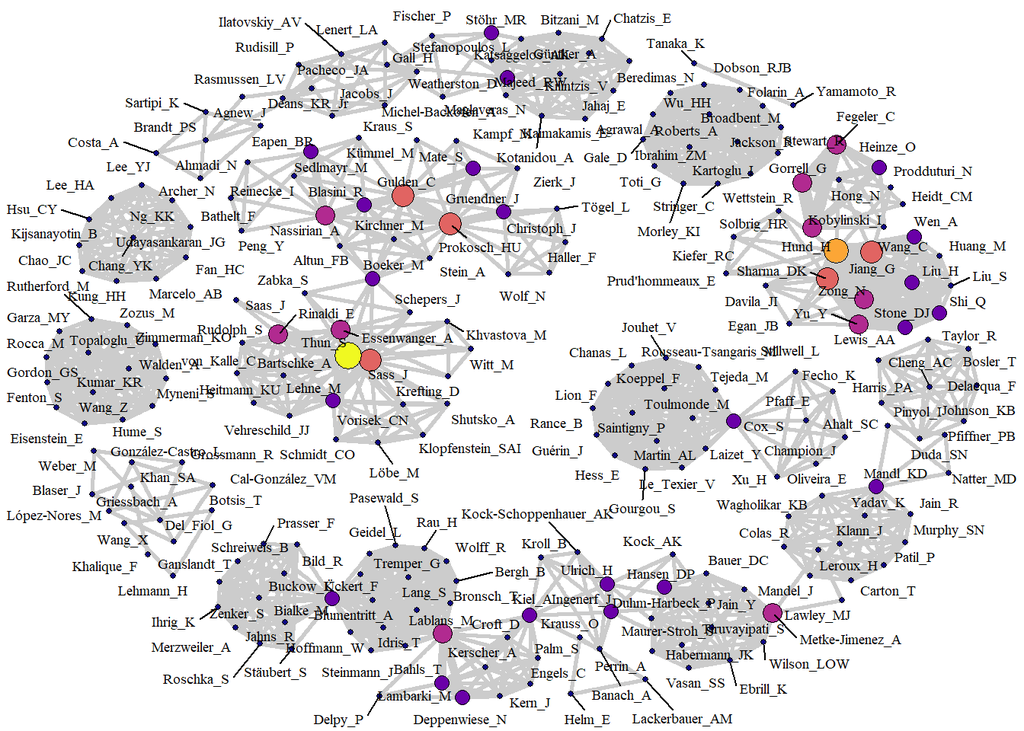

```r
plot_network <- ggraph(network_authors, layout = "kk") +
        geom_edge_link(aes(width = collaborations), color = "grey80") +
        geom_node_point(aes(fill = as.factor(publications), size = publications),
                        shape = 21) +
        #geom_node_point(aes(size = publications)) +
        geom_node_text(aes(label = name), repel = TRUE, size = 2.5,
                       family = "serif") +
        scale_edge_width(range = c(1, 4))+
        scale_fill_viridis_d(option = "C") +
        guides(fill = "none", size = "none", width = "none") +
        theme_void() +
        theme(legend.position = "none")

plot_network
```

## author information

```r
nrow(authors)
```

```
## [1] 256
```

```r
summary(authors$publications)
```

```
##    Min. 1st Qu.  Median    Mean 3rd Qu.    Max.
##   1.000   1.000   1.000   1.258   1.000   6.000
```

```r
author_info <- authors %>%
  group_by(publications) %>%
  summarize(N = n()) %>%
  mutate(Percent = N / sum(N) * 100,
         Percent = round(Percent, 1)) %>%
  arrange(desc(N))

knitr::kable(author_info)
```

| publications | N | Percent |
| --- | --- | --- |
| 1 | 217 | 84.8 |
| 2 | 22 | 8.6 |
| 3 | 10 | 3.9 |
| 4 | 5 | 2.0 |
| 5 | 1 | 0.4 |
| 6 | 1 | 0.4 |

# Analysis of Excel file

## Data import and cleaning

Import Excel file with included studies (“IncludedStudies2.xlsx”):

```r
excel_data <- read_excel("IncludedStudies2.xlsx")
```

Clean data (keep only variables relevant for analysis, rename variables, reformat, …):

```r
excel_data_clean <- excel_data %>%
  select(Author = `Author (First)`,
         Title,
         Year,
         Country = `Country (according to 1st author affiliation)`,
         Item_mapped_keyword = `Item mapped_keyword`,
         Goal_keyword,
         Other_standards_keyword = `Other standards_keyword`,
         Other_software_keyword = `Other Software_keyword`,
         FHIR_resource_used = `FHIR Resource used`,
         FHIR_extension_used = `FHIR extension used`,
         FHIR_version = `FHIR version`,
         Patients,
         Variables,
         Variables_count,
         Research_category = `Research Category`,
         Medical_area = `Medical Area`,
         Journal,
         Impact_factor = `Impact Factor Research)`,
         Research_area = `Research Area`,
         Clinical_trials = `Clinical Trials`,
         generic,
         SNOMED_CT = `Other standards - SNOMED CT`,
         LOINC = `Other standards - LOINC`,
         ICD_10 = `Other standards - ICD 10`,
         OMOP = `Other standards - OMOP`,
         Other = `Other standards - Other`,
         None = `Other standards - None (nicht angegeben oder nicht verwendet)`) %>%
  mutate(Journal = str_trim(Journal)) %>%
  mutate(Journal = ifelse(Journal %in%  c("Studies in Health technology and informatics", "Studies in Health Technology and Informatics"),
                          "Studies in health technology and informatics", Journal)) %>%
  mutate(Journal = ifelse(Journal == "JMIR medical informatics",
                          "JMIR Medical Informatics", Journal)) %>%
  mutate(Impact_factor = ifelse(Impact_factor %in% c("None", "-"), NA, Impact_factor)) %>%
  mutate(Impact_factor = str_replace(Impact_factor, ",", ".")) %>%
  mutate(Impact_factor = round(as.numeric(Impact_factor), 2)) %>%
  mutate(Country = ifelse(Country == "USA / Switzerland", "USA", Country)) %>%
  mutate(Research_area = ifelse(Research_area == "Clinical trials",
                               "Clinical Trials", Research_area))
```

## Analysis

### Publications per year

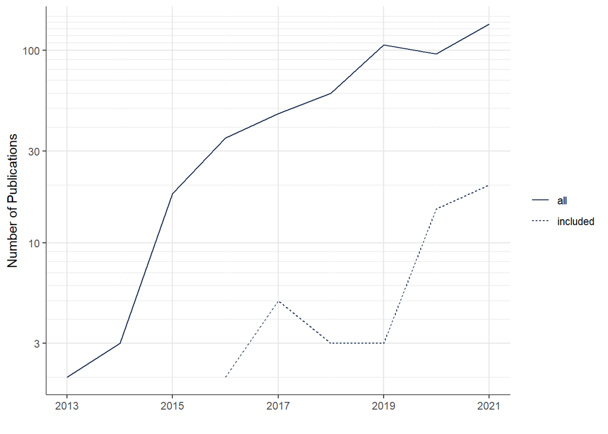

```r
# all articles
pub_all <- read_excel("articles_figure1.xlsx")

# number of publications per year (all articles)
pub_all_year <- pub_all %>%
  group_by(year) %>%
  summarize(n = n()) %>%
  filter(year < 2022) %>%
  mutate(Articles = "all")

# number of publications per year (included articles)
pub_included_year <- excel_data_clean %>%
  group_by(Year) %>%
  summarize(n = n()) %>%
  filter(Year < 2022) %>%
  mutate(Articles = "included") %>%
  rename(year = Year)

# combine in one data frame
pub_year <- rbind(pub_all_year, pub_included_year)
pub_year$year <- as.integer(pub_year$year)

# plot
plot_pub <- ggplot(pub_year) + geom_line(aes(year, n, linetype = Articles),
                             color = "#1b3051") +
  labs(x = "", y = "Number of Publications", linetype = "") +
  scale_y_log10(minor_breaks = c(seq(1,9), seq(10,150,10))) +
  theme(rect = element_blank(),
        axis.line = element_line(color = "grey40"),
        panel.grid.major = element_line(color = "grey90"),
        panel.grid.minor.y = element_line(color = "grey90"))

plot_pub + scale_x_continuous(limits = c(2013, 2021), breaks = c(2013, 2015, 2017, 2019, 2021))
```

Summary publications per year

```r
summary(excel_data_clean$Year)
```

```
##    Min. 1st Qu.  Median    Mean 3rd Qu.    Max.
##    2016    2019    2020    2020    2021    2022
```

### Countries

The articles originate from the following countries (according to affiliation of first author):

```r
countries <- excel_data_clean %>%
  group_by(Country) %>%
  summarize(N = n()) %>%
  mutate(Percent = N / sum(N) * 100,
         Percent = round(Percent, 1)) %>%
  arrange(desc(N))

knitr::kable(countries)
```

| Country | N | Percent |
| --- | --- | --- |
| Germany | 23 | 46.9 |
| USA | 13 | 26.5 |
| Australia | 3 | 6.1 |
| Austria | 1 | 2.0 |
| Canada | 1 | 2.0 |
| France | 1 | 2.0 |
| Greece | 1 | 2.0 |
| Japan | 1 | 2.0 |
| Pakistan | 1 | 2.0 |
| Spain | 1 | 2.0 |
| Switzerland | 1 | 2.0 |
| Taiwan | 1 | 2.0 |
| UK | 1 | 2.0 |

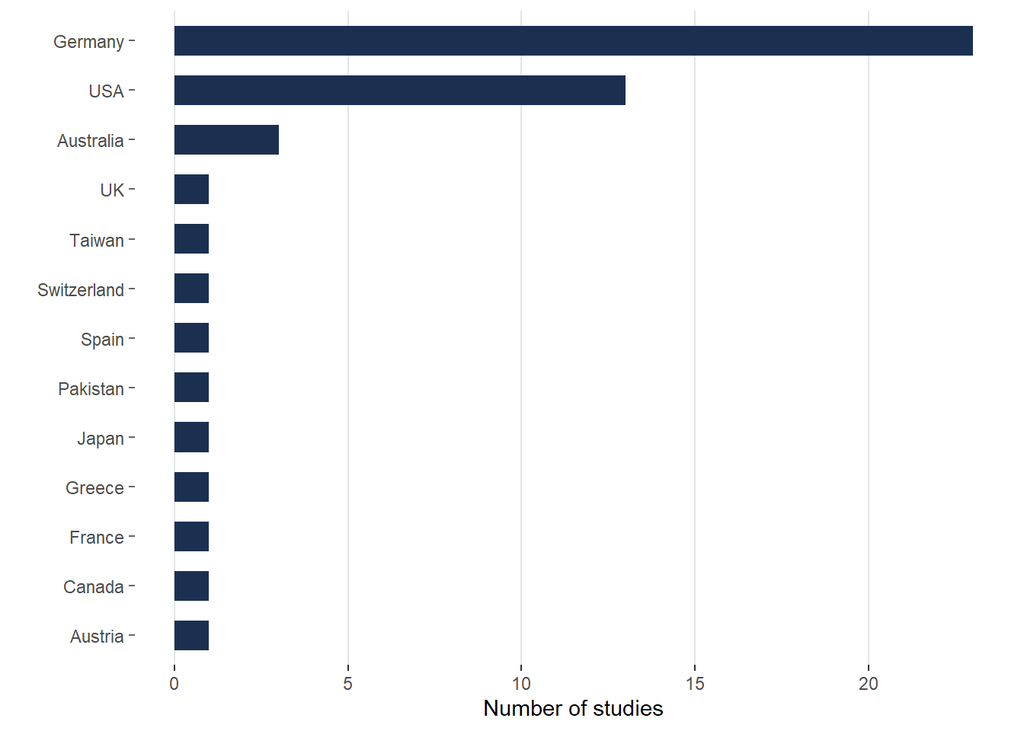

```r
# define theme and colors for barplots
bar_theme <-   theme(rect = element_blank(),
        axis.ticks.y = element_line(color = "grey40"),
        panel.grid.major.x = element_line(color = "grey90"))
bar_color <-  "#1b3051"
bar_width <- 0.6

plot_country <- ggplot(countries) +
  geom_col(aes(reorder(Country, N, sum), N), fill = bar_color,
           width = bar_width) +
  labs(x = "", y = "Number of studies") +
  scale_y_continuous(breaks = seq(0,30,5)) +
  coord_flip() +
  scale_color_manual(values = "#668dcc") +
  bar_theme

plot_country
```

### Journals

The articles were published in the following scientific journals:

```r
journals <- excel_data_clean %>%
  group_by(Journal) %>%
  mutate(N = n()) %>%
  select(Journal, Impact_factor, N) %>%
  distinct() %>%
  ungroup() %>%
  mutate(Percent = N / sum(N) * 100,
         Percent = round(Percent, 1)) %>%
  arrange(desc(N))

knitr::kable(journals)
```

| Journal | Impact_factor | N | Percent |
| --- | --- | --- | --- |
| Studies in health technology and informatics | 0.68 | 23 | 45.1 |
| BMC medical informatics and decision making | 2.80 | 3 | 5.9 |
| JMIR Medical Informatics | 2.96 | 2 | 3.9 |
| AMIA Joint Summits on Translational Science proceedings | NA | 2 | 3.9 |
| Journal of the American Medical Informatics Association | 4.69 | 2 | 3.9 |
| Journal of the American Medical Informatics Association | 4.50 | 2 | 3.9 |
| Transboundary and emerging diseases | 4.80 | 1 | 2.0 |
| Journal of Translational Medicine | 4.96 | 1 | 2.0 |
| Journal of medical Internet research | 5.18 | 1 | 2.0 |
| 2017 IEEE 11th International Conference on Application of Information and Communication Technologies (AICT) | NA | 1 | 2.0 |
| Journal of medical systems | 5.23 | 1 | 2.0 |
| Journal of biomedical semantics | 3.24 | 1 | 2.0 |
| PLOS One | 3.24 | 1 | 2.0 |
| JCO clinical cancer informatics | 2.95 | 1 | 2.0 |
| International Journal of Medical Informatics | 4.05 | 1 | 2.0 |
| AMIA Joint Summits on Translational Science | NA | 1 | 2.0 |
| JMIR MEDICAL INFORMATICS | 2.96 | 1 | 2.0 |
| Journal of Biomedical Informatics | 6317.00 | 1 | 2.0 |
| JAMIA Open | NA | 1 | 2.0 |
| JCO Clin Cancer Inform | 2.95 | 1 | 2.0 |
| Journal of biomedical informatics | 6.32 | 1 | 2.0 |
| healthcare | 1.58 | 1 | 2.0 |
| AMIA Annual Symposium Proceedings | 1.28 | 1 | 2.0 |

### Research category

Articles were grouped into the following research categories:

```r
categories <- excel_data_clean %>%
  group_by(Research_category) %>%
  summarize(N = n()) %>%
  mutate(Percent = N / sum(N) * 100,
         Percent = round(Percent, 1)) %>%
  arrange(desc(N))

knitr::kable(categories)
```

| Research_category | N | Percent |
| --- | --- | --- |
| Standardization of data | 20 | 40.8 |
| Data capture | 14 | 28.6 |
| Recruitment | 7 | 14.3 |
| Analysis | 6 | 12.2 |
| Consent management | 2 | 4.1 |

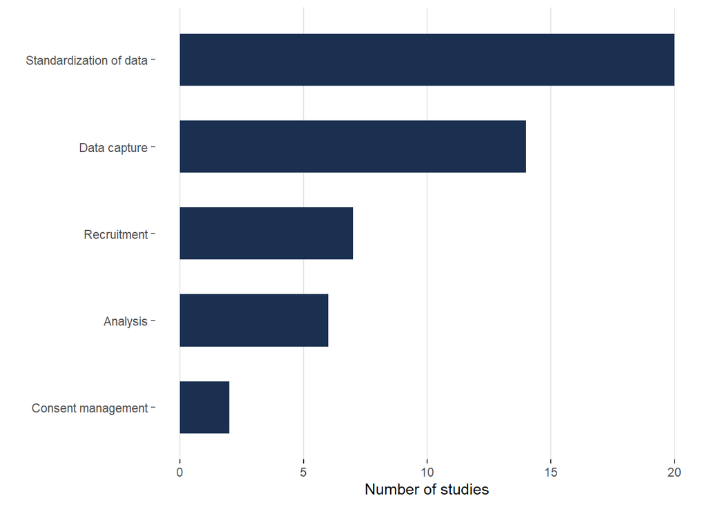

```r
plot_category <- ggplot(categories) + geom_col(aes(reorder(Research_category, N, sum), N),
                              fill = bar_color,
                              width = bar_width) +
  labs(x = "", y = "Number of studies") +
  scale_y_continuous(breaks = seq(0,20,5)) +
  coord_flip() +
  bar_theme

plot_category
```

Most articles reported generic solutions:

```r
table(excel_data_clean$generic)
```

```
##
##  No Yes
##  11  38
```

### Medical area

Articles were grouped into the following medical areas:

```r
medical_area <- excel_data_clean %>%
  group_by(Medical_area) %>%
  summarize(N = n()) %>%
  mutate(Percent = N / sum(N) * 100,
         Percent = round(Percent, 1)) %>%
  arrange(desc(N))

knitr::kable(medical_area)
```

| Medical_area | N | Percent |
| --- | --- | --- |
| Generic | 27 | 55.1 |
| Infectious Disease | 8 | 16.3 |
| Oncology | 6 | 12.2 |
| Genomics | 4 | 8.2 |
| Environmental health | 1 | 2.0 |
| Genomic cancer medicine | 1 | 2.0 |
| Neuroimaging research | 1 | 2.0 |
| Pulmonary Hypertension | 1 | 2.0 |

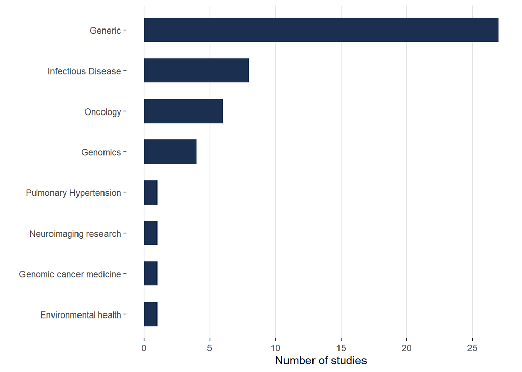

```r
plot_medical <- ggplot(medical_area) + geom_col(aes(reorder(Medical_area, N, sum), N),
                                fill = bar_color,
                                width = bar_width) +
  labs(x = "", y = "Number of studies") +
  scale_y_continuous(breaks = seq(0,30,5)) +
  coord_flip() +
  bar_theme

plot_medical
```

### Research area

Articles were grouped into the following research areas:

```r
research_area <- excel_data_clean %>%
  group_by(Research_area) %>%
  summarize(N = n()) %>%
  mutate(Percent = N / sum(N) * 100,
         Percent = round(Percent, 1)) %>%
  arrange(desc(N))

knitr::kable(research_area)
```

| Research_area | N | Percent |
| --- | --- | --- |
| Clinical Research | 26 | 53.1 |
| Clinical Trials | 10 | 20.4 |
| Research not specified | 10 | 20.4 |
| Public Health/ Epidemiological Studies | 3 | 6.1 |

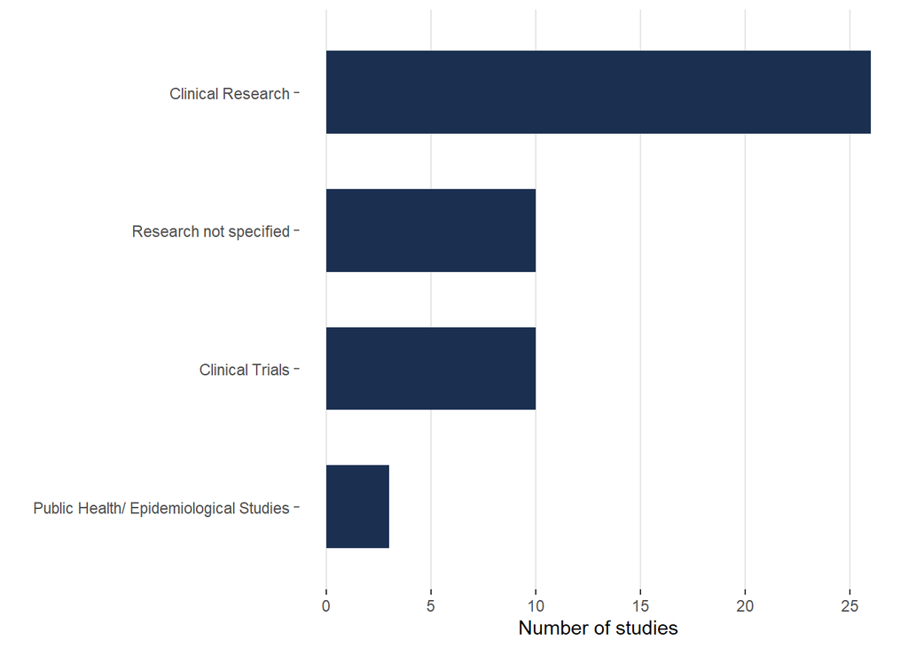

```r
plot_area <- ggplot(research_area) +
  geom_col(aes(reorder(Research_area, N, sum), N),
           fill = bar_color,
           width = bar_width) +
  labs(x = "", y = "Number of studies") +
  scale_y_continuous(breaks = seq(0,30,5)) +
  coord_flip() +
  bar_theme

plot_area
```

## Plot clinical trials as part of clinical research:

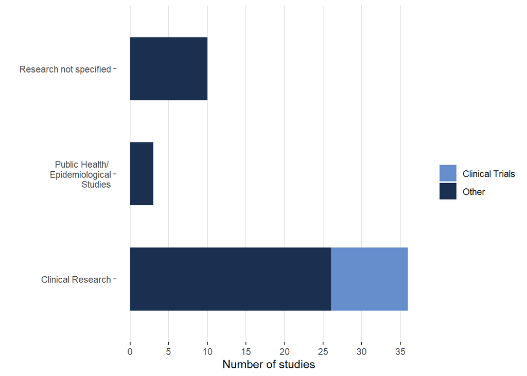

```r
plot_data <- excel_data_clean %>%
  mutate(Clinical_trials = ifelse(Research_area == "Clinical Trials",
                                  "Clinical Trials", "Other")) %>%
  mutate(Research_area = ifelse(Research_area == "Clinical Trials",
                                "Clinical Research", Research_area)) %>%
  mutate(Research_area = ifelse(Research_area == "Public Health/ Epidemiological Studies", "Public Health/ \n Epidemiological\n Studies", Research_area))

plot_clinical <- ggplot(plot_data) +
  geom_bar(aes(Research_area,
               fill = Clinical_trials), width = bar_width) +
  labs(x = "", y = "Number of studies", fill = "") +
  scale_y_continuous(breaks = seq(0,35,5)) +
  scale_fill_manual(values=c("#668dcc", "#1b3051")) +
  coord_flip() +
  bar_theme

plot_clinical
```

### Standards

The following other standards and terminologies were used in the studies:

```r
standards <- excel_data_clean %>%
  select(SNOMED_CT:None) %>%
  gather("Standard", "used") %>%
  group_by(Standard) %>%
  summarize(N = sum(used)) %>%
  mutate(Percent = N / nrow(excel_data_clean) * 100,
         Percent = round(Percent, 1)) %>%
  arrange(desc(N))

knitr::kable(standards)
```

| Standard | N | Percent |
| --- | --- | --- |
| Other | 21 | 42.9 |
| LOINC | 18 | 36.7 |
| None | 18 | 36.7 |
| SNOMED_CT | 14 | 28.6 |
| ICD_10 | 9 | 18.4 |
| OMOP | 6 | 12.2 |

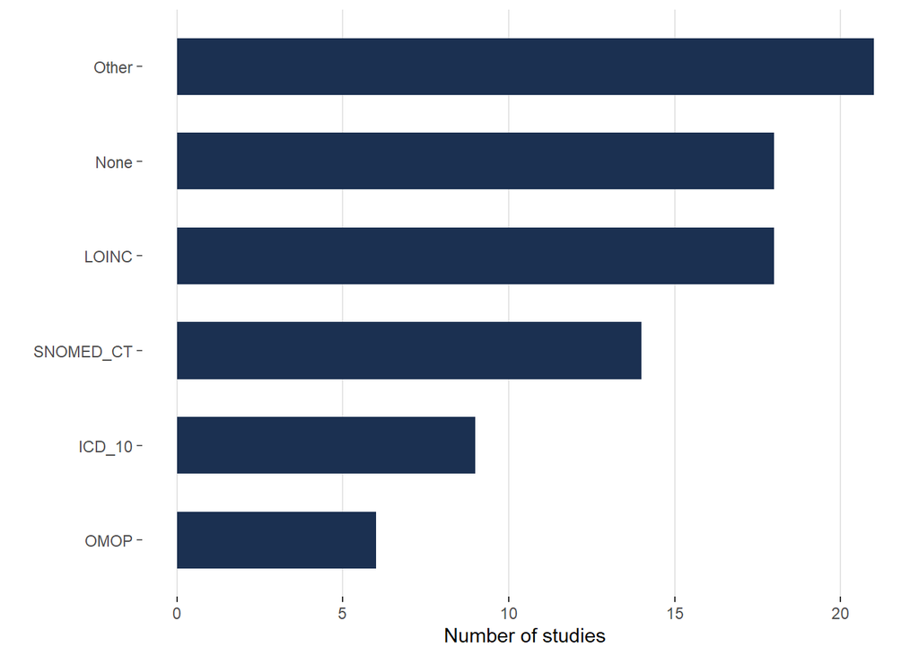

```r
plot_standards <- ggplot(standards) + geom_col(aes(reorder(Standard, N, sum), N),
                             fill = bar_color,
                             width = bar_width) +
  labs(x = "", y = "Number of studies") +
  scale_y_continuous(breaks = seq(0,21,5)) +
  coord_flip() +
  bar_theme

plot_standards
```

### Goals

This section analyzes the most common keywords describing the goals of the articles.

Load tidytext package and get word frequencies of all words in Goal_keyword variable:

```r
library(tidytext)

# define some stop words to be excluded
stop_words <- c("of", "and", "for", "from", "a", "an", "between",
                "across", "on", "the", "to", "in", "into", "with",
                "as", "or", "other", "such", "via")

goal_keywords <- excel_data_clean %>%
  select(Goal_keyword) %>%
  unnest_tokens(word, Goal_keyword, to_lower = TRUE) %>%
  filter(!(word %in% stop_words)) %>%
  group_by(word) %>%
  summarize(freq = n()) %>%
  arrange(desc(freq))
```

The wordcloud shows the most common words mentioned as keywords:

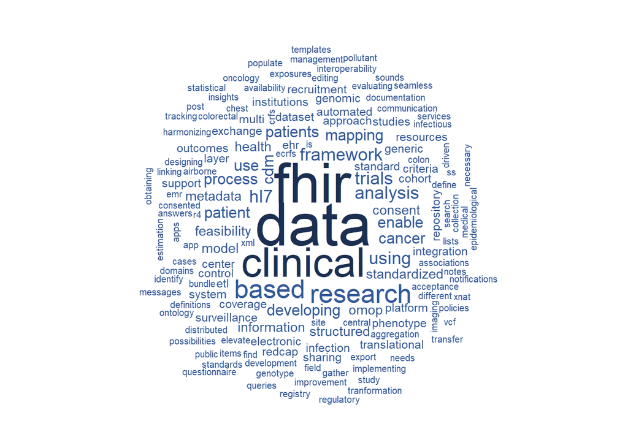

```r
library(wordcloud)
wordcloud(words = goal_keywords$word, freq = goal_keywords$freq, min.freq = 1,                      max.words=150, random.order=FALSE, rot.per=0.10,
             colors=c("#335a99", "#1b3051"))
```

# Create Images for Publication out of multiple graphs

Package gridExtra

```r
library(gridExtra)
```

```r
require(gridExtra)
plot1 <- ggplot(categories) + geom_col(aes(reorder(Research_category, N, sum), N),
                              fill = bar_color,
                              width = bar_width) +
  labs(x = "", y = "Number of studies") +
  scale_y_continuous(breaks = seq(0,20,5)) +
  coord_flip() +
  bar_theme
plot2 <- ggplot(standards) + geom_col(aes(reorder(Standard, N, sum), N),
                             fill = bar_color,
                             width = bar_width) +
  labs(x = "", y = "Number of studies") +
  scale_y_continuous(breaks = seq(0,21,5)) +
  coord_flip() +
  bar_theme
```

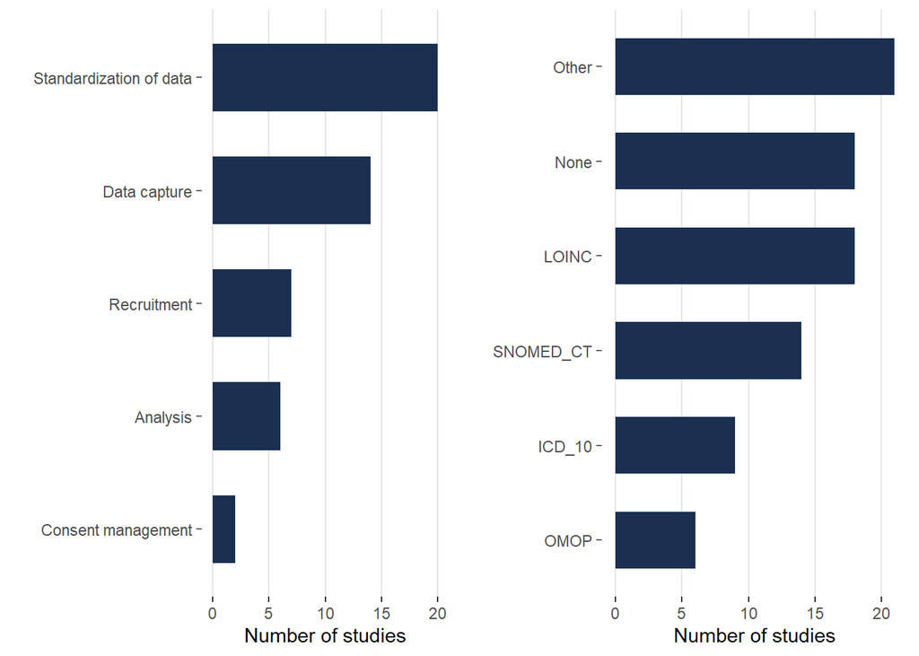

```r
test <- grid.arrange(plot1, plot2, ncol=2)
```

```r
test
```

```r
ggsave("test.png", arrangeGrob(plot1, plot2))
```

package cowplot

```r
library(cowplot)
```

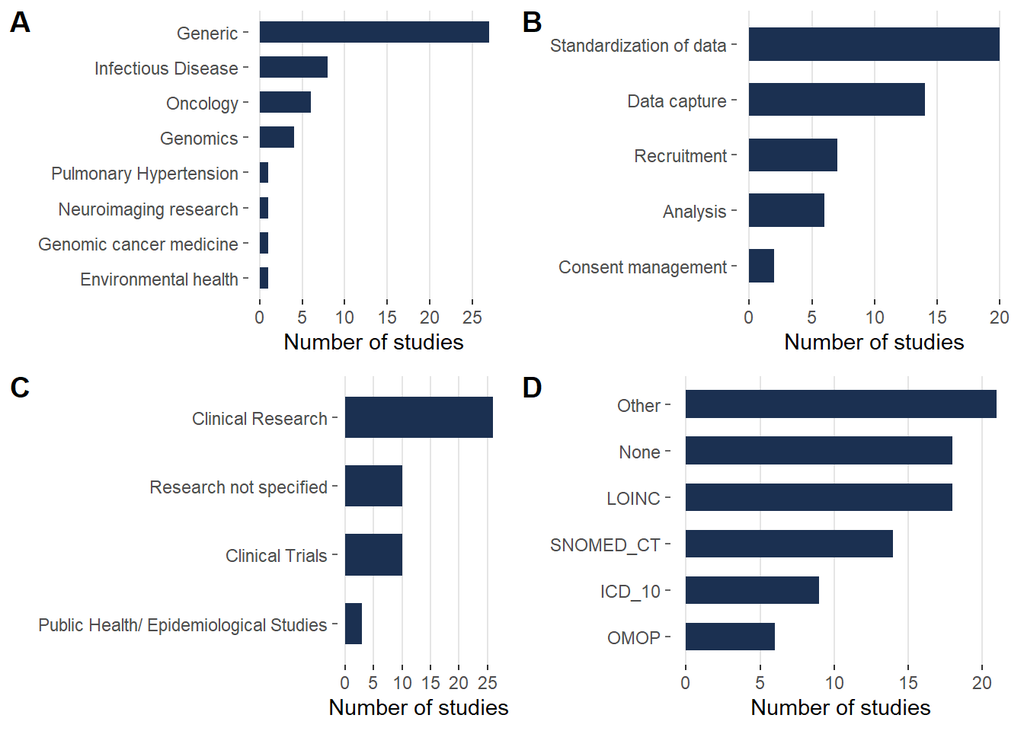

```r
p2 <- plot_grid(plot_medical, plot_category, plot_area, plot_standards, labels = "AUTO")
p2
```

## Save Images for Publication

```r
ggsave("Figure5test.png", p2)
ggsave("Figure2.png", plot_pub)
ggsave("Figure3.png", plot_network)
ggsave("Figure4A.png", plot_country)
ggsave("Figure5A.png", plot_medical)
ggsave("Figure5B.png", plot_category)
ggsave("Figure5C.png", plot_clinical)
ggsave("Figure5D.png", plot_standards)
```